# Deriving Financial Formulas Using Geometric Series

### Sum of a Geometric Series

Excel’s built-in functions are useful only if you depend entirely on spreadsheets to generate financial numbers. If you already understand the common finance terms and their meanings, but want to know more about the mathematics behind it (perhaps you want write a simple financial program), it is important to realise that most calculations involving loans and bonds comes from the time value of moeny formula. Take a look at some of the financial functions available in Excel - IRR, FV, NPV, PMT, PRICE and YIELD. They are all derived from the same formula; the only difference is the input you provide as function variables required under different purpose and assumptions. It is also worth noting that where lengthy time series make computation more tedious, one of the most useful formula to apply is the geometric series formula. Most of you will recall learning it in algebra class but never had the chance to use it in real life. Blame it on computers, maybe, but we have come to be more familiar with the name of mathematical functions than the actual formula itself.

The sum of the first *n* terms of a geometric progression is given by:

$$S_n=a~+~ar~+~ar^2~+~...~+ ar^{n-1}$$
Notice the similarity with formulas such as the time value of multiple cash flows.

$Present Value=\frac{C_1}{(1+r)^1}+\frac{C_2}{(1+r)^2}+\frac{C_3}{(1+r)^3}+...\frac{C_n}{(1+r)^n}$

Calculation using the expanded form can be tedious When *n* is large. Fortunately, we can use a simple formula.

$S_n=a+ar+ar^2+ar^3+...+ar^{n-3}+ar^{n-2}+ar^{n-1}$

$S_n=a+r(a+ar+ar^2+...+ar^{n-3}+ar^{n-2})$

$S_n=a+r(S_n-ar^{n-1})$

$S_n=a+rS_n-ar^n$

$S_n-rS_n=a-ar^n$

$S_n(1-r)=a(1-r^n)$

$$S_n=\frac{a(1-r^n)}{1-r}$$

Using this formula, we can find the present value by substituting:

$S_n = PV$, $a=\frac{C}{1+r}$, $r=\frac{1}{1+r}$, $n=n$

and we get:

$$PV=C~\frac{1-(1+r)^{-n}}{r}$$

### Periodic Payment Formula

[output not shown]

P = $200,000  
r = 0.005 (6.0% p.a. divided by 12)  
n = 24 (number of periods or months up to maturity)

$A = \frac{200,000*0.005(1+0.005)^{24}}{(1+0.005)^{24}-1} = 8,864.12$

**Deriving the formula**

Forget about the above formula for a moment. With only information on *p*, *r* and *n*, you can easily calculate the first month’s interest amount. That’s probably as far as you get with the schedule without performing any trial and error. What method might you think of to determine a series of fixed amount that spreads out the principal repayment nicely across two years, pay interest according to the monthly balance and be left owing nothing at the end?

It is quite obvious to most that the present values of all monthly payments received in equal amounts must add up to the initial loan principal. This is translated into the present value formula:

$$P=\frac{A}{(1+r)}+\frac{A}{(1+r)^2}+\frac{A}{(1+r)^3}+\frac{A}{(1+r)^4}+...\frac{A}{(1+r)^n}$$

```
        where
               P = Present Value of all future payments
               A = Constant Payment Amount
               r = Periodic interest
               n = Number of periods
```

In other words, we want to achieve a series of numbers like Column “O” of the payment schedule, in which the summation of all the present value interest and principal payments compensates for the initial loan principal. Since the only known variables at this point are *P*, *r* and *n*, to find *A*, we need to simplify and re-arrange the formula.

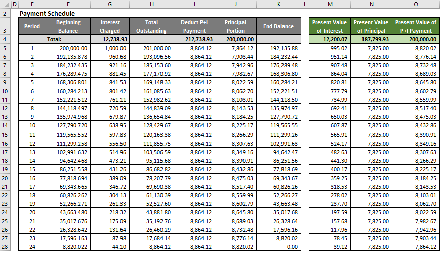

From the previous section, we know that the sum of the geometric series formula is: $S_n = \frac{a(1-r^n)}{(1-r)}$. Re-arranging it, we get $a = \frac{S_n(1-r)}{1-r^n}$

From the present value formula, if $\frac{A}{(1+r)}$ represents the 1<sup>st</sup> term of the geometric series *a*, $\frac{1}{(1+r)}$ the common ratio *r*, *n* the number of terms in the series, and *P* the sum, then substituting these into $a = \frac{S_n(1-r)}{1-r^n}$:

$$\frac{A}{(1+r)}=\frac{P(1-\frac{1}{(1+r)})}{1-\frac{1}{(1+r)^n}}$$

$$A=\frac{P(\frac{r}{(1+r)})(1+r)}{\frac{(1+r)^n-1}{(1+r)^n}}$$

$$A=\frac{Pr(1+r)^n}{(1+r)^n-1}$$